# Слоговая структура македонского языка

Ксения Романова Национальный исследовательский институт “Высшая школа экономики” Научный руководитель: Г.А.Мороз

18-окт-2018 **Международная конференция «Балканские языки и диалекты: корпусные и квантитативные исследования»**

## Македонский язык

< Macedo-Bulgarian < Eastern South Slavic < South Slavic < Slavic < Balto-Slavic < Indo-European

## Фонетическая система: согласные

| Место образования | Губно-губные | Губно-зубные | Зубные | Альвеолярные | Альвео-палатальные | Палатальные | Велярные |
| --- | --- | --- | --- | --- | --- | --- | --- |
| Способ образования |  |  |  |  |  |  |  |
| Взрывные | p *⟨п⟩* b *⟨б⟩* |  | t *⟨т⟩* d *⟨д⟩* |  |  | c *⟨ќ⟩* ɟ *⟨ѓ⟩* | k *⟨к⟩* ɡ *⟨г⟩* |
| Щелевые |  | f *⟨ф⟩* v *⟨в⟩* | s *⟨с⟩* z *⟨з⟩* |  | ʃ *⟨ш⟩* ʒ *⟨ж⟩* |  | x *⟨х⟩* |
| Аффрикаты |  |  | t̪͡s̪ *⟨ц⟩* d̪͡z̪ *⟨ѕ⟩* |  | t͡ʃ *⟨ч⟩* d͡ʒ *⟨џ⟩* |  |  |
| Глайды |  |  |  |  |  | j *⟨й⟩* |  |
| Боковые |  |  | l *⟨л⟩* |  |  |  |  |
| Носовые | m *⟨м⟩* |  | n *⟨н⟩* |  |  | ɲ *⟨њ⟩* |  |
| Дрожащие |  |  |  | r *⟨р⟩* |  |  |  |

*таблица 1. Консонантная система македонского языка*

## Фонетическая система: гласные

| Ряд | Передний | Средний | Задний |
| --- | --- | --- | --- |
| Подъём | Неогубленные | Неогубленные | Огубленные |
| Верхний | i *⟨и⟩* |  | u *⟨у⟩* |
| Средний | ɛ *⟨е⟩* | (ə) | ɔ *⟨о⟩* |
| Нижний |  | a *⟨а⟩* |  |

*таблица 2. Вокалическая система македонского языка*

## Описание фонотактической структуры

инициаль — ядро — финаль

- инициаль — согласные, предшествующие ядру
- финаль — согласные, следующие за ядром
- ядро — вершина слога

## Методы определения принципов слогоделения

**Экспериментально** (Côté and Kharlamov 2010):

- **Вставка паузы** *(Pause Insertion)*: ко-[пауза]-шка, кош-[пауза]-ка;
- **Перестановка слогов** *(Syllable Reversal/Permutation)*: шка-ко, ка-кош;
- **Редупликация слога** *(Syllable Reduplication)*: ко-ко-шка, кош-кош-ка;
- **Повторение n-ого слога** *(Syllable Repetition)*: кошка-ко, кошка-кош;
- **Замена слога на другим** *(Syllable Substitution)*: кошка > бушка (замена слога ко-), бука (замена слога кош-);
- **Вставка другого элемента** *(Fragment Insertion)*: кошка ⇒ ‘я говорю *ко* и затем *шка*’

**Элицитация** (Duanmu 2009)

## Методология

Частичная автоматизации анализа слоговой структуры (Czerniak 2015), (Мороз 2019)

Для македонского языка было размечено 53468 слов  
- из рассмотрения были исключены: сокращения, сложные слова, междометия

## Методология (1)

1. На основании грамматического описания (Friedman 2002) выделены единицы, которые могут составлять ядро слога:
- гласные
- слоговые:
  - р в начале слова перед согласным: *рж*
  - р в позиции между двумя согласными: *грст*
  - р, л, н в конце слова после согласного: *тембр*, *шатл*, *ансамбл*, *артикл*, *бинокл*, *њутн*

## Методология (2)

В упрощёном виде:

- S (sonorant)
  - r, l, m, n, j, lj, nj
- O (obstruent)
  - p, b, v, f, t, d, ts, dz, s, z, tʃ, dʒ, ʃ, ʒ, c, ɟ, k, ɡ, x
- V (vocalic)
  - всё, что может быть вершиной слога: a, o, u, e, i, L, N, R
2. На основе всего имеющегося лексического материала выделены:
- все возможные инициали первых слогов слов
- все возможные финали последних слогов слов

## Инициали

|  | quality_initials | frequency |
| --- | --- | --- |
| 1 | O | 24183 |
| 2 | S | 10561 |
| 3 | V | 7855 |
| 4 | O-S | 6723 |
| 5 | O-O | 3130 |
| 6 | O-O-S | 822 |
| 7 | S-S | 150 |
| 8 | O-O-O | 22 |
| 9 | O-S-S | 20 |
| 10 | O-O-O-S | 2 |

## Инициали: *O-O-O-S* — исключение

- **встр**ана
- **вшпр**ица

## Финали

|  | quality_finals | frequency |
| --- | --- | --- |
| 1 | V | 31911 |
| 2 | S | 10898 |
| 3 | O | 8168 |
| 4 | O-O | 1907 |
| 5 | S-O | 543 |
| 6 | S-S | 25 |
| 7 | S-O-O | 10 |
| 8 | O-O-O | 5 |
| 9 | S-S-O | 1 |

## Методология (3)

3. На основе полученных данных составлена общая модель слога

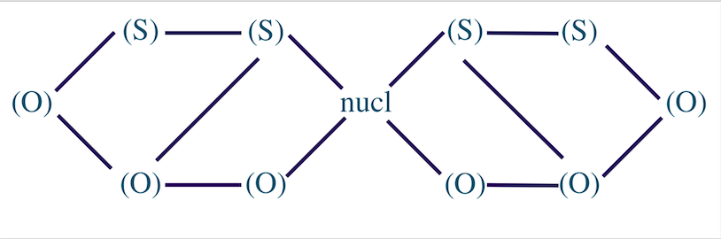

*Рис.1. Модель слога. S — сонорные, O — шумные, nucl — ядро слога.*

## Методология (4)

4. Тестирование полученной модель на всём материале:
- проверка на интервокальных кластерах

**Если** обнаруживаются слова, в которых интервокальные кластеры нельзя объяснить полученной моделью

=> уточнение модели с учётом “исключений”

## Анализ кластеров согласных

модель описывает все слова:

|  | Предсказанные кластеры | Количество подходящих кластеров |
| --- | --- | --- |
| 1 | Кластеры согласных | 179558 |
| 2 | N/A | 44324 |
| 3 | Всего | 223882 |

## Методология (5)

5. Составлен список всех возможных комбинаций выделенных инициалей и финалей

[?] порождает ли модель какие-то кластеры которые не были бы представлены в языке

## Комбинации кластеров

|  | syllables_in_words | presence |
| --- | --- | --- |
| 1 | SVSOO | True |
| 2 | OOSVSO | True |
| 3 | OOOVSO | True |
| 4 | OOVS | True |
| 5 | OSSVO | True |
| 6 | OVSO | True |
| 7 | SSVSO | True |
| 8 | SVO | True |
| 9 | OOOVSS | True |
| 10 | SVSS | True |

[output cut: 58 more lines]

## Методология (5): да, перепорождает

слоги которые она перепорождает

OSSVOOO  
SSVSSO  
OSSVSSO  
OOSVSSO  
OOOVSSO

5,88% слогов

## Методология (5): упрощение модели, ограничения

OSS V OOO  
SS V SSO  
OSS V SSO  
OOS V SSO  
OOO V SSO

S-S-O: аjнц

OOS V OOO: здравствен, здравство

## Интервокальные кластеры: волновой характер слога

Разные типы языков (Кодзасов and Муравьева 1980):

- “квантовые” языки
  - слог характеризуется пограничными сигналами, которые маркируют его границы
- “волновые” языки
  - границы слога не маркируются
  - ко-шка vs кош-ка (Князев 1999)

## Интервокальные кластеры: строгие фонотактические правила

для македонского языка неизвестны строгие фонотактические правила

Язык гуро (Выдрин 2008):

- V, CV, CVV, CVV2, CVLV, CVlV2

Теория сонорности (Clements 1990) предсказывает распределение разных типов сегментов относительно ядра.

## Модель: упрощение

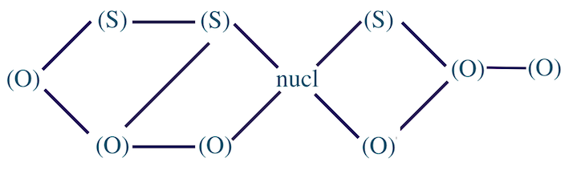

*Рис.1. Модель слога. S — сонорные, O — шумные, nucl — ядро слога.*

## Некоторая литература

Clements, George N. 1990. “The Role of the Sonority Cycle in Core Syllabification.” *Papers in Laboratory Phonology* 1: 283–333.

Côté, Marie-Hélène, and Viktor Kharlamov. 2010. “The Impact of Experimental Tasks on Syllabification Judgments: A Case Study of Russian.” In *Handbook of the Syllable*, 271–94. Brill.

Czerniak, Tomasz. 2015. “Word-Initial Clusters in Welsh: A Typological Analysis.” *Young Minds Vs. Old Questions in Linguistics*, 29.

Duanmu, San. 2009. *Syllable Structure: The Limits of Variation*. Oxford University Press.

Friedman, Victor A. 2002. “Macedonian (Languages of the World/Materials 117).” *München: LINCOM Europa*.

Выдрин, ВФ. 2008. “Метрическая стопа в языках манде.” *Фонетика и нефонетика: К*, 308–17.

Князев, С.В. 1999. “О критериях слогоделения в современном русском языке: Теория волны сонорности и теория оптимальности.” *Вопросы языкознания*, no. 1: 84–102.

Кодзасов, С.В., and И.А. Муравьева. 1980. “Слог и ритмика слова в алюторском языке.” *Публикации отделения структурной и прикладной лингвистики МГУ. Филологический факультет*, no. 9.

Мороз, Г.А. 2019. “Слоговая структура адыгейского языка: От данных к обобщениям.” *Вопросы языкознания*, no. в печати.